# Inference of Cell-cell Communication for Signaling Pathways using TWCOM

24 January, 2024

```r
library(TWCOM)
library(Seurat)
library(CellChat)
```

This vignette demonstrates the detailed steps of inference and visualization of cell-cell communication for signaling pathways from spatially resolved transcriptomics (SRT) data. The corresponding data are from GSE144240.

The entire process should be very similar to [the tutorial for ligand-receptor pairs](https://dongyuanwu.github.io/assets/tutoridal/TWCOM_Introduction.html). The only difference is that we need the `pathways` information aligned with `ligands` and `receptors`, and pass them into `FRETCOMPathway()` to obtain the inference results.

For illustrative purposes, we exclusively utilize spot-based SRT data in this context. For guidance on handling single-cell resolution data, please refer to [the tutorial for ligand-receptor pairs](https://dongyuanwu.github.io/assets/tutoridal/TWCOM_Introduction.html).

# 1 Data and preprocessing

**SRT gene expression matrix:** A gene expression matrix for the SRT data is necessary. Genes should be organized in rows with corresponding row names, while spots should be organized in columns with appropriate column names.

```r
data(STdata)
STdata[1:5, 1:5]  # raw count data
```

```
#>            spot1 spot2 spot3 spot4 spot5
#> FO538757.1     0     0     0     1     1
#> NOC2L          1     0     1     0     1
#> KLHL17         0     0     0     0     0
#> PLEKHN1        0     0     0     0     0
#> HES4           0     0     0     0     2
```

We require that the input gene expression matrix has been normalized. Here, we use `Seurat` to normalize the original gene expression matrix.

```r
dat <- CreateSeuratObject(counts=STdata, meta.data=STmeta)
dat <- NormalizeData(dat, assay = "RNA", scale.factor=10000)
stdat <- dat@assays$RNA@data
stdat[1:5, 1:5]  # normalized data
```

```
#> 5 x 5 sparse Matrix of class "dgCMatrix"
#>               spot1 spot2    spot3    spot4     spot5
#> FO538757.1 .            . .        1.405807 0.4925826
#> NOC2L      2.245586     . 1.729187 .        0.4925826
#> KLHL17     .            . .        .        .
#> PLEKHN1    .            . .        .        .
#> HES4       .            . .        .        0.8211333
```

**SRT location information:** A data frame containing X and Y coordinates for each spot is also necessary.

```r
data(STmeta)
head(STmeta)
```

```
#>        spot  x  y
#> spot1 spot1 10 10
#> spot2 spot2 10 12
#> spot3 spot3 10 14
#> spot4 spot4 10 16
#> spot5 spot5 10 18
#> spot6 spot6 10 20
```

**Cell type proportion matrix:** The information on cell type proportions can be obtained from upstream cell type deconvolution software, such as [RCTD](https://github.com/dmcable/spacexr), STRIDE, and SPOTlight. In this matrix, rows represent spots, and columns represent cell types.

```r
data(MExample)
MExample[1:5, 1:5]
```

```
#>               ASDC       B Cell         CD1C       CLEC9A     Eccrine
#> spot1 2.397727e-05 2.397727e-05 2.397727e-05 2.858981e-02 0.023976096
#> spot2 3.707897e-05 3.707897e-05 3.707897e-05 3.433518e-02 0.038124145
#> spot3 2.885173e-02 3.586799e-05 3.586799e-05 3.586799e-05 0.035130044
#> spot4 3.479057e-05 3.479057e-05 3.479057e-05 8.699541e-03 0.007237430
#> spot5 1.570955e-03 2.343515e-07 2.343515e-07 1.811005e-02 0.001934116
```

**Ligand-receptor pairs and their corresponding signaling pathways information:**

Users can obtain ligand-receptor pairs from different public databases, such as [CellChatDB](https://github.com/jinworks/CellChat), [CellPhoneDB](https://github.com/ventolab/CellphoneDB), and CellTalkDB. Here, we use `CellChat` as an example. It is important to note that `CellChat` supports subunits for ligands or receptors, and we organize them in a `list` format. If the database does not have any subunit settings, users can directly organize them in a `vector` format. They just need to ensure that the order of ligands and receptors can be matched.

```r
lrdb <- CellChatDB.human
ligands <- receptors <- vector(mode="list", length=nrow(lrdb$interaction))
pathways <- NULL

for(i in 1:length(ligands)) {

    pathways <- c(pathways, lrdb$interaction$pathway_name[i])

    if(!(lrdb$interaction$ligand[i] %in% rownames(lrdb$complex))) {
        ligands[[i]] <- lrdb$interaction$ligand[i]
    } else {
        ltemp <- c(lrdb$complex[rownames(lrdb$complex) == lrdb$interaction$ligand[i], ])
        ltemp <- ltemp[nzchar(ltemp)]
        ligands[[i]] <- ltemp
    }

    if(!(lrdb$interaction$receptor[i] %in% rownames(lrdb$complex))) {
        receptors[[i]] <- lrdb$interaction$receptor[i]
    } else {
        ltemp <- c(lrdb$complex[rownames(lrdb$complex) == lrdb$interaction$receptor[i], ])
        ltemp <- ltemp[nzchar(ltemp)]
        receptors[[i]] <- ltemp
    }

}
ligands <- lapply(ligands, unlist)
receptors <- lapply(receptors, unlist)
```

# 2 Inferring cell-cell communication

The necessary inputs for `FRETCOMPathway()` include the normalized gene expression matrix (`stdat`), the cell type proportion matrix (`M`), the X and Y coordinates (`coordx` and `coordy`), the known ligand-receptor pairs (`ligands` and `receptors`), the known corresponding pathway names (`pathways`), and the maximum distance allowed for communication (`maxdist`). It is important to note that a reasonable `maxdist` should be set based on the units of `coordx` and `coordy` provided.

Here, for simplicity, we use only two pathways (`TGFb` and `WNT`) as examples.

```r
ligands <- ligands[pathways %in% c("TGFb", "WNT")]
receptors <- receptors[pathways %in% c("TGFb", "WNT")]
pathways <- pathways[pathways %in% c("TGFb", "WNT")]
restab <- FRETCOMPathway(stdat=stdat, M=MExample, ligands=ligands, receptors=receptors,
                         pathways=pathways, coordx=STmeta$x, coordy=STmeta$y, maxdist=3,
                         parallel=TRUE)
```

```
#> 244 out of 332 LR pairs have been removed due to their non-existence in SRT data.
```

```r
restab[1:5, ]
```

```
#>   Pathway CellType_Sender CellType_Receiver    Estimate       Pvalue
#> 1    TGFb            ASDC              ASDC -0.22204952 5.564773e-05
#> 2    TGFb            ASDC            B Cell -0.12823974 4.603280e-02
#> 3    TGFb            ASDC              CD1C -0.01904899 4.562327e-01
#> 4    TGFb            ASDC            CLEC9A -0.06478358 1.733416e-02
#> 5    TGFb            ASDC           Eccrine  0.05537185 1.260267e-02
#>        Qvalue
#> 1 0.001689934
#> 2 0.173600826
#> 3 0.661902802
#> 4 0.090345357
#> 5 0.074966402
```

# 3 Visualization

In practice, we highly recommend that users generate figures using the results data frame (`restab`) themselves so that features in the figures, such as titles, colors, and font sizes, can be adjusted flexibly. However, we still provide two functions `CCCHeatmap()` and `CCCNetwork()` here for simple visualizations.

## 3.1 Heatmap

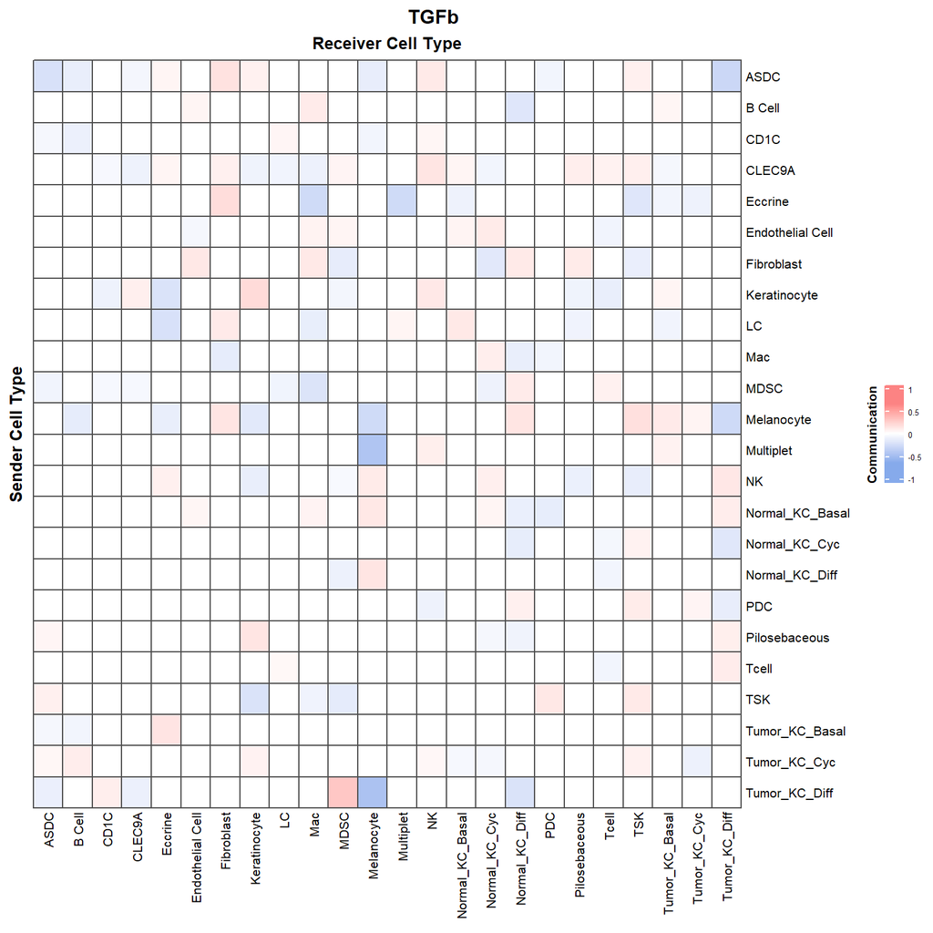

```r
CCCHeatmap(restab, pathway="TGFb")
```

In addition to the specific signaling pathway, user can also visualize the overall cell-cell communication results.

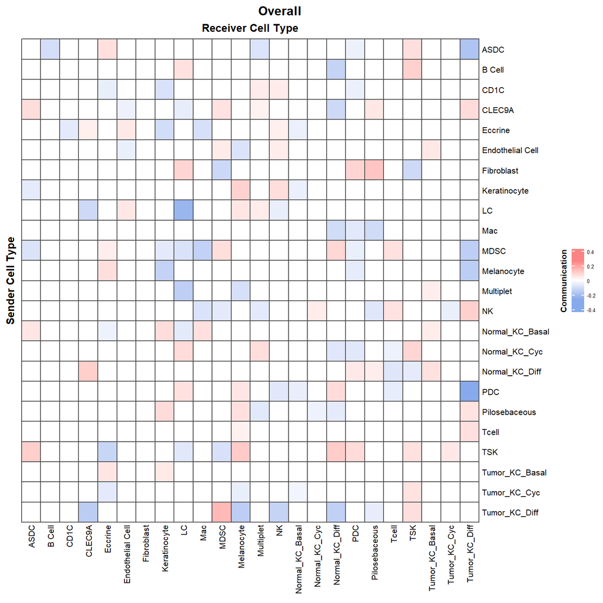

```r
CCCHeatmap(restab, pathway="Overall")
```

## 3.2 Network

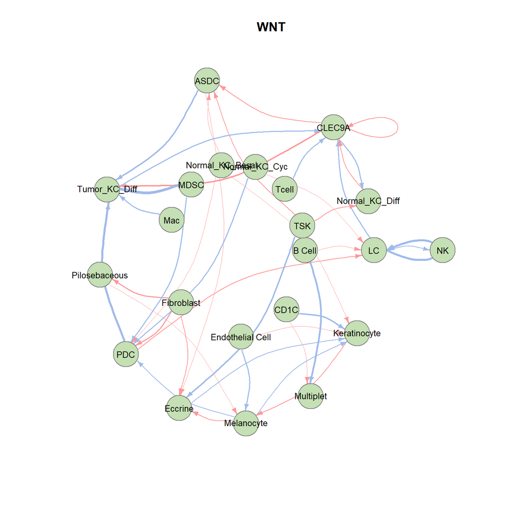

```r
CCCNetwork(restab, cutoff=0.01, pathway="WNT")
```

In addition to the specific signaling pathway, user can also visualize the overall cell-cell communication results.

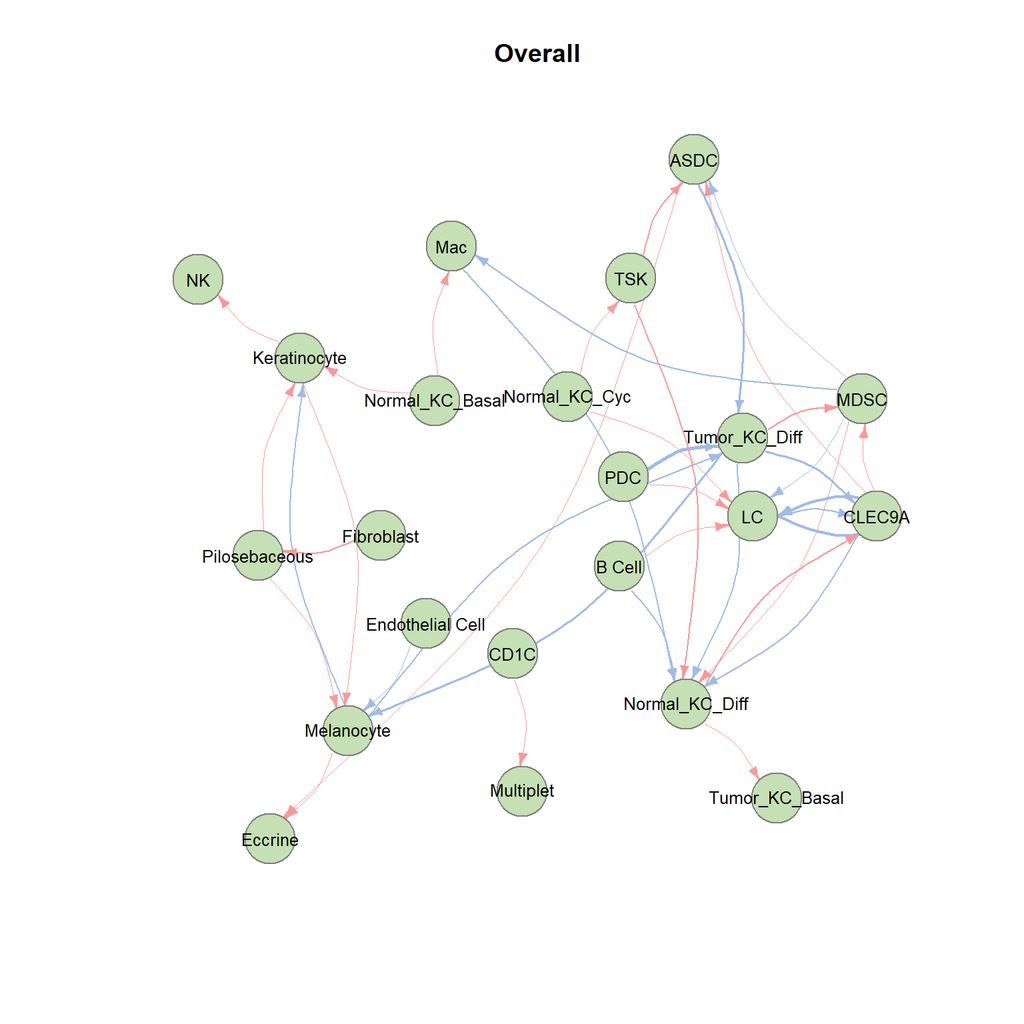

```r
CCCNetwork(restab, cutoff=0.01, pathway="Overall")
```